# Model-agnostic methods: Partial Dependency Plot (PDP)

Natalia Martínez, Elena Orón, Aitana Sebastià

24 maig, 2024

```r
# setwd("C:/Users/natal/Downloads/EDM/PL Tema 5/Practica 5/")
setwd("C:/Users/34686/3CD - 23_24/EDM/XAI3")
```

# Libraries

```r
# library(randomForest)

# Data preparation
library(dplyr)
# Data partition
library(caret)
# PDP
library(pdp)
library(ggplot2)
```

# 1. Bike-rental database

## Data

```r
day <- read.csv("day.csv")
hour <- read.csv("hour.csv")
```

## Data preprocessing

```r
## We prepare the new variables

# We just include 3 out of the 4 features to undo the correlation
day$season = factor(day$season)
season_one_hot = model.matrix(~ 0 + season, data = day)

# One-hot encoding
misty = ifelse(day$weathersit==2,1,0)
rain = ifelse(day$weathersit %in% c(3,4),1,0)

# Unnormalize: temp -> (t-t_min)/(t_max-t_min), t_min=-8, t_max=+39 (only in hourly scale)
temp = (39+8)*day$temp -8

# Unnormalize: hum -> The values are divided to 100 (max)
hum = day$hum*100

# Unnormalize: windspeed -> The values are divided to 67 (max)
windspeed = day$windspeed*67

# length(day$dteday) --> 731 days
days_since_2011 =  seq(0,365*2)
dim(day)
```

```r
day_new = data.frame(day$cnt, day$workingday, day$holiday, season_one_hot[,-1], misty, rain, temp, hum, windspeed, days_since_2011)
names(day_new)[1:6] = c("cnt", "workingday", "holiday", "spring", "summer", "fall")
day_new
```

The partial dependence plot shows the marginal effect of a feature on the predicted outcome of a previously fit model.

Apply PDP to the regression example of predicting bike rentals. Fit a random forest approximation for the prediction of bike rentals (cnt). Use the partial dependence plot to visualize the relationships the model learned. Use the slides shown in class as model.

Generate a 2D Partial Dependency Plot with humidity and temperature to predict the number of bikes rented depending on those parameters.

BE CAREFUL: due to the size, extract a set of random samples from the BBDD before generating the data for the Partial Dependency Plot.Show the density distribution of both input features with the 2D plot as shown in the class slides.  
TIP: Use geom_tile() to generate the 2D plot. Set width and height to avoid holes.

## Random Forest

```r
set.seed(123)

# Using randomForest library
# rf <- randomForest(formula = cnt ~ ., data = day_new)

# Train and test split
index <- createDataPartition(day_new$cnt, p = .8, list = FALSE)
day_train <- day_new[ index, ]
day_test <- day_new[-index, ]

# Model building
rf_day <- train(cnt ~ . , data = day_train, method = "rf")
```

## One dimensional Partial Dependence Plot

General function to plot the required variables.

```r
# Define the function to generate the PDP plot
generate_pdp_plot <- function(model, pred_var, var_name, train_data, y_name="Predicted bike rentals", grid_resolution = 20) {
  # Generate the PDP data for the specified variable
  pdp_data <- partial(model, pred.var = pred_var, train = train_data, grid.resolution = grid_resolution)

  # Convert the PDP data to a data frame
  pdp_df <- as.data.frame(pdp_data)

  # Generate the PDP plot
  pdp_plot <- ggplot(pdp_df) +
    geom_line(aes_string(x = pred_var, y = "yhat"), color = "black") +  # Line for the PDP
    geom_rug(data = train_data, aes_string(x = pred_var), sides = "b") +
    theme_minimal() +
    labs(title = paste("Partial dependence plot for", var_name),
         x = pred_var, y = y_name)

  # Return the PDP plot
  return(pdp_plot)
}
```

Plot the PDP for numerical variables:

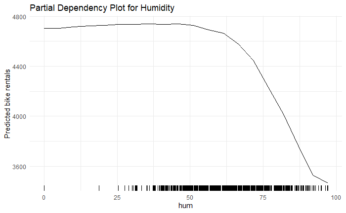

```r
pdp_plot_hum <- generate_pdp_plot(rf_day, "hum", "Humidity" ,day_new)
print(pdp_plot_hum)
```

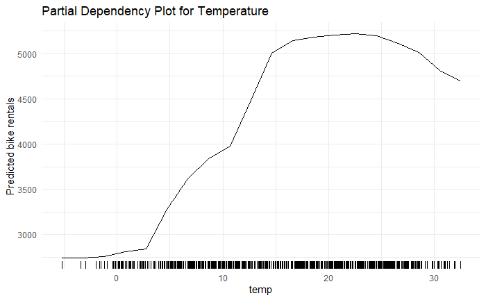

```r
pdp_plot_temp <- generate_pdp_plot(rf_day, "temp", "Temperature" ,day_new)
print(pdp_plot_temp)
```

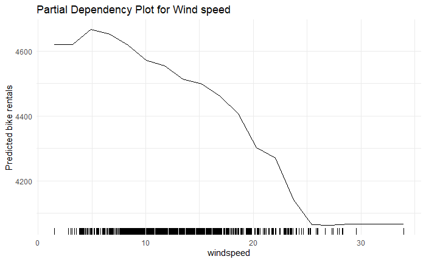

```r
pdp_plot_windspeed <- generate_pdp_plot(rf_day, "windspeed", "Wind speed",day_new)
print(pdp_plot_windspeed)
```

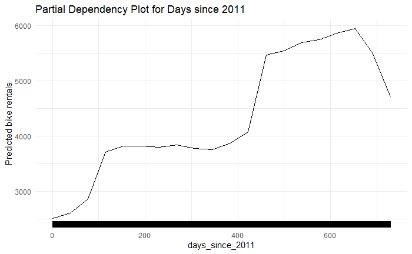

```r
pdp_plot_days_since_2011 <- generate_pdp_plot(rf_day, "days_since_2011", "Days since 2011",day_new)
print(pdp_plot_days_since_2011)
```

```r
NA
NA
```

## Bidimensional Partial Dependence Plot

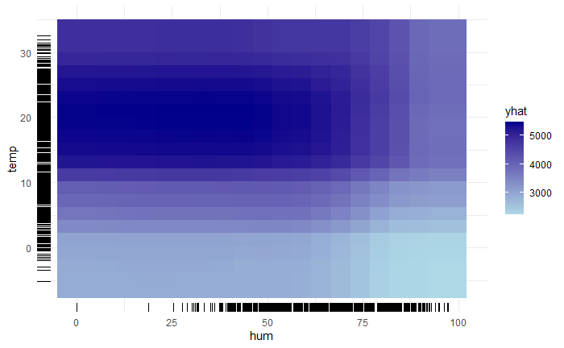

```r
# Generate PDP data for humidity and temperature
pdp_data <- partial(rf_day, pred.var = c("hum", "temp"), train = day_new, grid.resolution = 20)

# Convert the pdp_data to a data frame
pdp_df <- as.data.frame(pdp_data)

# Normalize yhat values between 0 and 1
#pdp_df$yhat <- (pdp_df$yhat - min(pdp_df$yhat)) / (max(pdp_df$yhat) - min(pdp_df$yhat))


# Generate the 2D plot using geom_tile()
pdp_2d_plot <- ggplot(pdp_df, aes(x = hum, y = temp, fill = yhat)) +
  geom_tile() +
  scale_fill_gradient(low = "blue", high = "red") +
  theme_minimal() +
  labs(title = "2D Partial Dependency Plot",
       x = "Humidity", y = "Temperature", fill = "Predicted Bike Rentals")

# Display the plot
ggplot() +
  geom_tile(data = pdp_df, aes(x = hum, y = temp, fill = yhat), width = 10, height = 5) +
  scale_fill_gradient(low = "lightblue", high = "darkblue") +
  geom_rug(data = day_new, aes(x = hum), sides = "b") +
  geom_rug(data = day_new, aes(y = temp), sides = "l") +
  theme_minimal()
```

# 2. House price database

Apply the previous concepts to predict the price of a house from the database kc_house_data.csv. In this case, use again a random forest approximation for the prediction based on the features bedrooms, bathrooms, sqft_living, sqft_lot, floors and yr_built. Use the partial dependence plot to visualize the relationships the model learned.

BE CAREFUL: due to the size, extract a set of random samples from the BBDD before generating the data for the Partial Dependency Plot.

## Data

```r
house = read.csv("kc_house_data.csv")
```

```r
library(dplyr)
```

```r
library(caret)
```

## One dimensional Partial Dependence Plot

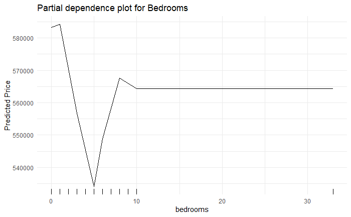

```r
pdp_plot_bedrooms <- generate_pdp_plot(rf_house, "bedrooms", "Bedrooms" ,house_sample, "Predicted Price")
print(pdp_plot_bedrooms)
```

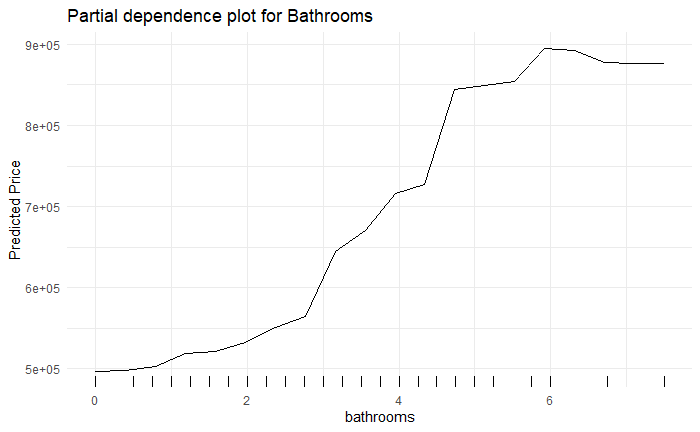

```r
pdp_plot_bathrooms <- generate_pdp_plot(rf_house, "bathrooms", "Bathrooms" ,house_sample, "Predicted Price")
print(pdp_plot_bathrooms)
```

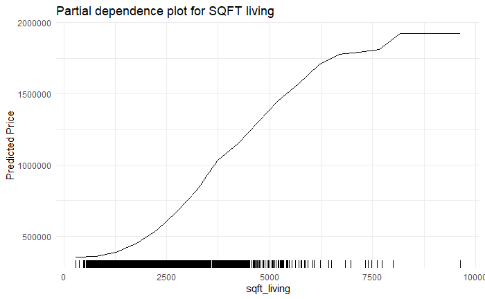

```r
pdp_plot_sqft_living <- generate_pdp_plot(rf_house, "sqft_living", "SQFT living",house_sample, "Predicted Price")
print(pdp_plot_sqft_living)
```

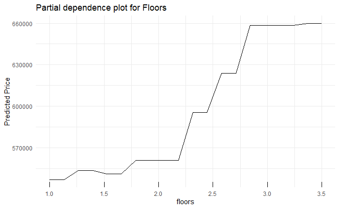

```r
pdp_plot_floors <- generate_pdp_plot(rf_house, "floors", "Floors", house_sample, "Predicted Price")
print(pdp_plot_floors)
```

```r
summary(house_sample)
```

```
     price            bedrooms        bathrooms      sqft_living      sqft_lot
 Min.   :  75000   Min.   : 0.000   Min.   :0.000   Min.   : 290   Min.   :    638
 1st Qu.: 320000   1st Qu.: 3.000   1st Qu.:1.625   1st Qu.:1430   1st Qu.:   5090
 Median : 450000   Median : 3.000   Median :2.250   Median :1920   Median :   7673
 Mean   : 542154   Mean   : 3.368   Mean   :2.112   Mean   :2086   Mean   :  14999
 3rd Qu.: 638600   3rd Qu.: 4.000   3rd Qu.:2.500   3rd Qu.:2550   3rd Qu.:  10620
 Max.   :5350000   Max.   :33.000   Max.   :7.500   Max.   :9640   Max.   :1164794
     floors         yr_built
 Min.   :1.000   Min.   :1900
 1st Qu.:1.000   1st Qu.:1953
 Median :1.000   Median :1975
 Mean   :1.493   Mean   :1972
 3rd Qu.:2.000   3rd Qu.:1997
 Max.   :3.500   Max.   :2015
```

## Bidimensional Partial Dependence Plot

[figure not shown]

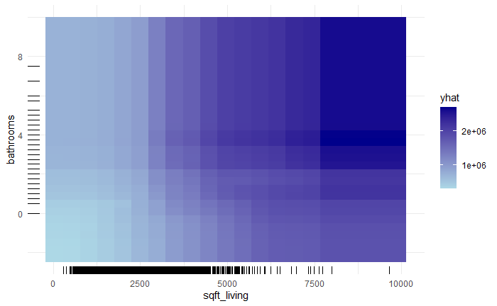

```r
# Generate PDP data for humidity and temperature
pdp_data <- partial(rf_house, pred.var = c("sqft_living", "bathrooms"), train = house_sample, grid.resolution = 20)

# Convert the pdp_data to a data frame
pdp_df <- as.data.frame(pdp_data)

# Normalize yhat values between 0 and 1
#pdp_df$yhat <- (pdp_df$yhat - min(pdp_df$yhat)) / (max(pdp_df$yhat) - min(pdp_df$yhat))


# Generate the 2D plot using geom_tile()
pdp_2d_plot <- ggplot(pdp_df, aes(x = sqft_living, y = bathrooms, fill = yhat)) +
  geom_tile() +
  scale_fill_gradient(low = "blue", high = "red") +
  theme_minimal() +
  labs(title = "2D Partial Dependency Plot",
       x = "SQFT living", y = "bathrooms", fill = "Predicted house prices")

# Display the plot
ggplot() +
  geom_tile(data = pdp_df, aes(x = sqft_living, y = bathrooms, fill = yhat), width = 1000, height = 5) +
  scale_fill_gradient(low = "lightblue", high = "darkblue") +
  geom_rug(data = house_sample, aes(x = sqft_living), sides = "b") +
  geom_rug(data = house_sample, aes(y = bathrooms), sides = "l") +
  theme_minimal()
```

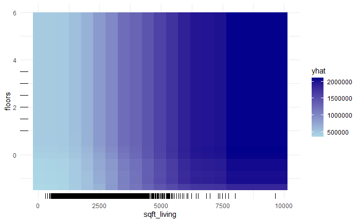

```r
# Generate PDP data for humidity and temperature
pdp_data <- partial(rf_house, pred.var = c("sqft_living", "floors"), train = house_sample, grid.resolution = 20)

# Convert the pdp_data to a data frame
pdp_df <- as.data.frame(pdp_data)

# Normalize yhat values between 0 and 1
#pdp_df$yhat <- (pdp_df$yhat - min(pdp_df$yhat)) / (max(pdp_df$yhat) - min(pdp_df$yhat))


# Generate the 2D plot using geom_tile()
pdp_2d_plot <- ggplot(pdp_df, aes(x = sqft_living, y = floors, fill = yhat)) +
  geom_tile() +
  scale_fill_gradient(low = "blue", high = "red") +
  theme_minimal() +
  labs(title = "2D Partial Dependency Plot",
       x = "SQFT living", y = "floors", fill = "Predicted house prices")

# Display the plot
ggplot() +
  geom_tile(data = pdp_df, aes(x = sqft_living, y = floors, fill = yhat), width = 1000, height = 5) +
  scale_fill_gradient(low = "lightblue", high = "darkblue") +
  geom_rug(data = house_sample, aes(x = sqft_living), sides = "b") +
  geom_rug(data = house_sample, aes(y = floors), sides = "l") +
  theme_minimal()
```